# Psych 254 W15 PS #3

Mike Frank

February 22, 2015

This is problem set #3, in which we want you to integrate your knowledge of data wrangling with some basic simulation skills and some linear modeling.

```r
library(dplyr)
library(ggplot2)
library(pander)
```

# Part 1: Basic simulation and NHST

Let’s start by convincing ourselves that t-tests have the appropriate false positive rate. Run 10,000 t-tests with standard, normally-distributed data from a made up 30-person, single-measurement experiment (the command for sampling from a normal distribution is `rnorm`). What’s the mean number of “significant” results?

First do this using a `for` loop.

```r
counter <- 0

for (i in 1:10000) {
  counter <- ifelse(t.test(rnorm(30))$p.value < 0.05, counter + 1, counter)
}
```

**Answer:** Out of 10,000 one-sample t-tests, 516 were significant, representing a false positive rate of 5.16%.

Next, do this using the `replicate` function:

```r
sim.fun <- function () t.test(rnorm(30))$p.value
sim.sig <- sum(replicate(10000, sim.fun()) < 0.05)
```

**Answer:** Out of 10,000 one-sample t-tests, 503 were significant, representing a false positive rate of 5.03%.

Ok, that was a bit boring. Let’s try something moderately more interesting - let’s implement a p-value sniffing simulation, in the style of Simons, Nelson, & Simonsohn (2011).

Consider this scenario: you have done an experiment, again with 30 participants (one observation each, just for simplicity). The question is whether their performance is above chance. You aren’t going to check the p-value every trial, but let’s say you run 30 - then if the p-value is within the range p < .25 and p > .05, you optionally run 30 more and add those data, then test again. But if the original p value is < .05, you call it a day, and if the original is > .25, you also stop.

First, write a function that implements this sampling regime.

```r
double.sample <- function () {
  d <- rnorm(30)
  result <- t.test(d)
  if (0.05 < result$p.value & result$p.value < 0.25) {
    d <- c(d, rnorm(30))
    result <- t.test(d)
  }
  return(result$p.value)
}
```

Now call this function 10k times and find out what happens.

```r
dbl.sig <- sum(replicate(10000, double.sample()) < 0.05)
```

Is there an inflation of false positives? How bad is it?

**Answer:** Out of 10,000 tests, 714 were significant, which amounts to a 7.14% false positive rate, or a 41.95% increase from the original false positive rate.

Now modify this code so that you can investigate this “double the sample” rule in a bit more depth. Let’s see what happens when you double the sample ANY time p > .05 (not just when p < .25), or when you do it only if p < .5 or < .75. How do these choices affect the false positive rate?

HINT: Try to do this by making the function `double.sample` take the upper p value as an argument, so that you can pass this through dplyr.

HINT 2: You may need more samples. Find out by looking at how the results change from run to run.

```r
double.sample <- function (p.upper) {
  d <- rnorm(30)
  result <- t.test(d)
  if (0.05 < result$p.value & result$p.value < p.upper) {
    d <- c(d, rnorm(30))
    result <- t.test(d)
  }
  return(result$p.value)
}

upper.fun <- function (x) sum(replicate(100000, double.sample(x)) < 0.05)
upper.sig <- data.frame(n = 100000, p = c(0.05, 0.25, 0.5, 0.75)) %>%
  mutate(sig = sapply(p, upper.fun),
         falsepos = round(sig/100000*100,2),
         pctchg = round((sig-sig[p == 0.05])/sig[p == 0.05]*100, 2))
```

What do you conclude on the basis of this simulation? How bad is this kind of data-dependent policy?

**Answer:** In all cases, ‘p-sniffing’ increased the false positive rate from 5.13%. As the upper-bound p increased, so too did the false positive rate: when $p_{upper} = 0.75$, the false positive rate was 60.23% higher than with no resampling. Therefore, re-sampling when the data are not significant considerably increases the risk of false discoveries.

# Part 2: The Linear Model

## 2A: Basic Linear Modeling

Let’s use the `ToothGrowth` dataset, on guineapig teeth based on orange juice and vitamin C. This is super simple. (Try `?ToothGrowth`).

First plot the data, we’ll use `qplot` to understand how `len` (tooth length) depends on `dose` (amount of Vitamin C) and `supp` (delivery method).

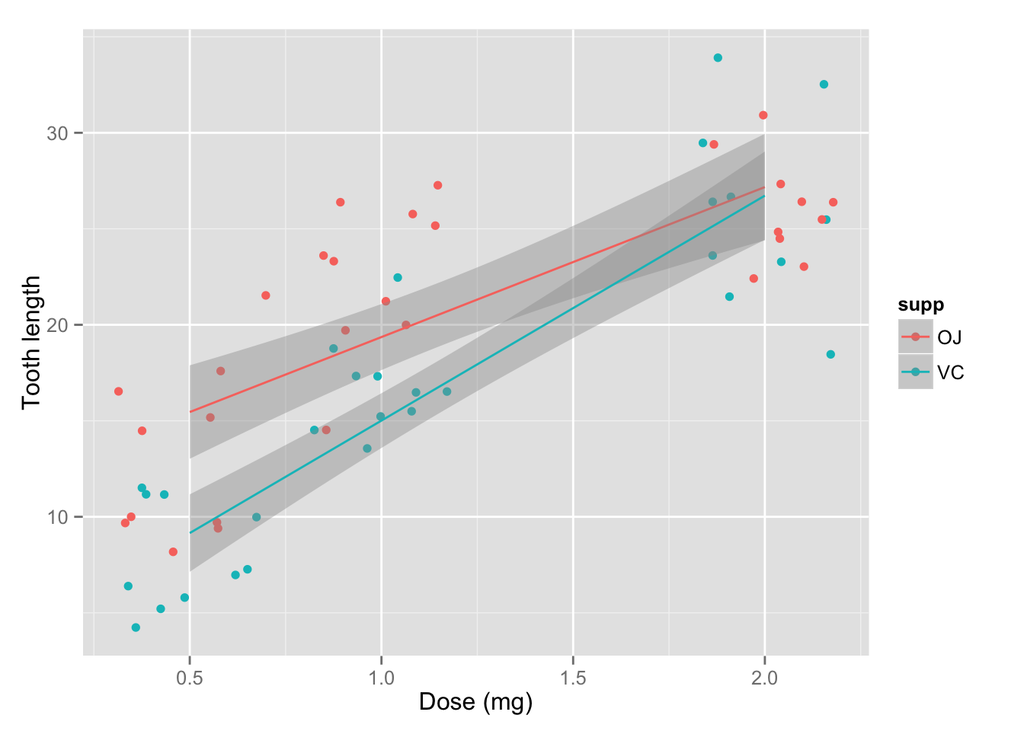

```r
qplot(dose, len, data = ToothGrowth, colour = supp, geom = c("jitter", "smooth"), width = 0.1, method = "lm", xlab = "Dose (mg)", ylab = "Tooth length")
```

So now you see what’s going on.

**Conclusion:** Tooth length increases linearly with vitamin C dosage. In addition, it seems that there may be a main effect of delivery method on tooth length, where guinea pigs who were administered orange juice have longer teeth, as well as an interaction between delivery method and dosage. However, it is not immediately obvious whether these are significant.

Next, always make a histogram of the DV before making a linear model! This reveals the distribution and can be helpful in choosing your model type.

```
## stat_bin: binwidth defaulted to range/30. Use 'binwidth = x' to adjust this.
```

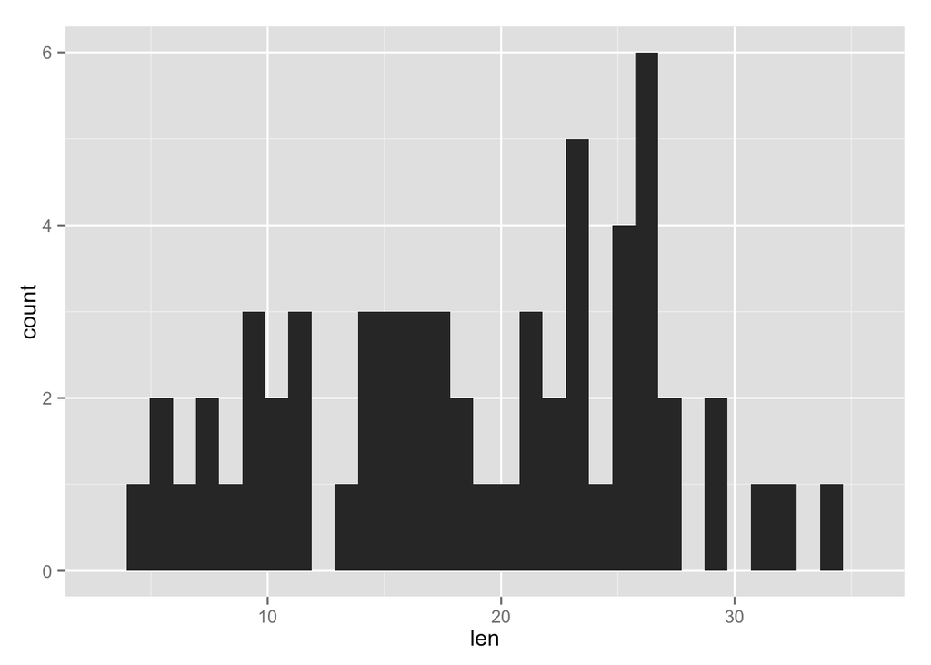

```r
qplot(len, data = ToothGrowth)
```

**Conclusion:** The data are *not* normally distributed; rather, they are negatively skewed.

Now make a linear model of tooth lengths using `lm`. Try making one with main effects and interactions and another with just main effects. Make sure to assign them to variables so that you can get them later.

```r
tooth.model <- lm(len ~ dose + supp, ToothGrowth)
tooth.model2 <- lm(len ~ dose * supp, ToothGrowth)
anova(tooth.model, tooth.model2)
```

```
## Analysis of Variance Table
##
## Model 1: len ~ dose + supp
## Model 2: len ~ dose * supp
##   Res.Df  RSS Df Sum of Sq    F Pr(>F)
## 1     57 1023
## 2     56  934  1      88.9 5.33  0.025 *
## ---
## Signif. codes:  0 '***' 0.001 '**' 0.01 '*' 0.05 '.' 0.1 ' ' 1
```

```r
summary(tooth.model2)
```

```
##
## Call:
## lm(formula = len ~ dose * supp, data = ToothGrowth)
##
## Residuals:
##    Min     1Q Median     3Q    Max
##  -8.23  -2.85   0.05   2.29   7.94
##
## Coefficients:
##             Estimate Std. Error t value Pr(>|t|)
## (Intercept)    11.55       1.58    7.30  1.1e-09 ***
## dose            7.81       1.20    6.53  2.0e-08 ***
## suppVC         -8.26       2.24   -3.69  0.00051 ***
## dose:suppVC     3.90       1.69    2.31  0.02463 *
## ---
## Signif. codes:  0 '***' 0.001 '**' 0.01 '*' 0.05 '.' 0.1 ' ' 1
##
## Residual standard error: 4.08 on 56 degrees of freedom
## Multiple R-squared:  0.73,   Adjusted R-squared:  0.715
## F-statistic: 50.4 on 3 and 56 DF,  p-value: 6.52e-16
```

Now try taking out the intercept, using a -1 term in the formula. what does this do?

```r
tooth.model3 <- lm(len ~ dose * supp -1, ToothGrowth)
```

**Conclusion:** Taking out the intercept dramatically improves model fit (with intercept: $R^2$ = 0.72; without intercept: $R^2$ = 0.96). It also changes how delivery method is evaluated. While the previous model compared average tooth length between the two delivery methods, this model tests the average tooth length of each group separately against 0.

Thought question: Take a moment to interpret the coefficients of the model. **Note:** The intercepts are more difficult to interpret when the intercept is removed, so the answers below refer to `tooth.model2`. Q1 - What are the units?

- dose ($\beta$ = 7.81) - increase in tooth length (in unspecified units) by unit of dosage (length units/mg)
- suppVC - difference in mean tooth length between the vitamin C and the orange juice groups (length units)
- dose:suppVC - difference in rate of change of tooth length by unit of dosage (length units/mg)

Q2 - How does the interaction relate to the plot?

The estimate of the interaction term is difference between the slope of the dose-length curve for the vitamin C group and the slope of the orange juice group. The sign of the coefficient indicates that this slope should be steeper for the vitamin C group than for the orange juice group, which is indeed reflected in the plot.

Q3 - Should there be an interaction in the model? What does it mean? How important is it?

The plot seemed to suggest that there would be an interaction in the model. One plausible interpretation for this interaction is that it reflects a constraint on guinea pig tooth length: while guinea pigs grow longer teeth when they are given orange juice, their teeth can only grow so much. Therefore, the interaction might not reflect anything about the “treatments” per se. How ‘important’ it is depends on the goal of the treatment: if it is to find the most efficient or cost-effective way to increase tooth length in guinea pigs, then the data suggest that orange juice is more effective at lower doses.

Now make predictions from the model you like the best. What should happen with doses of 0, 1.5, 2.5, and 10 under both supplements?

HINT: use the `predict` function …

HINT 2: you will have to make a dataframe to do the prediction with, so use something like `data.frame(dose=...)`.

```r
new.doses <- data.frame(supp = rep(c("OJ", "VC"), each = 4),
                        dose = rep(c(0, 1.5, 2.5, 10), 2))

new.doses$estimate <- predict(tooth.model2, new.doses)
pander(new.doses)
```

| supp | dose | estimate |
| --- | --- | --- |
| OJ | 0 | 11.55 |
| OJ | 1.5 | 23.27 |
| OJ | 2.5 | 31.08 |
| OJ | 10 | 89.66 |
| VC | 0 | 3.295 |
| VC | 1.5 | 20.87 |
| VC | 2.5 | 32.58 |
| VC | 10 | 120.5 |

Now plot the residuals from the original model. How do they look? HINT: `?resid`

```
## geom_smooth: method="auto" and size of largest group is <1000, so using loess. Use 'method = x' to change the smoothing method.
```

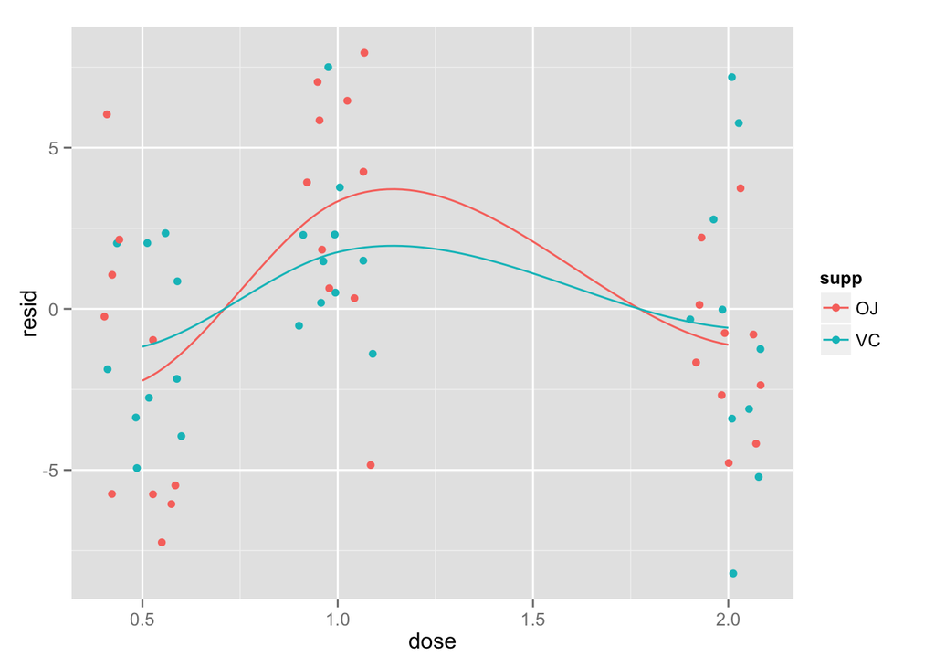

```r
d <- ToothGrowth
d$resid <- resid(tooth.model2)

ggplot(d, aes(x = dose, y = resid, colour = supp)) +
  geom_jitter(position = position_jitter(width = .1)) +
  geom_smooth(se = F)
```

** Conclusion:** There seems to be a non-random pattern in the residuals, suggesting that there is some explanatory information that is not accounted for by the model. (This non-random structure remains when the intercept is removed from the model.) It is possible that a linear fit is not the best way to capture the data, or that the data should have been fit to a different distribution (they did not seem normally distributed in the histogram above).

BONUS: test them for normality of distribution using a quantile-quantile plot.

HINT: `?qqplot` and `?qqnorm`

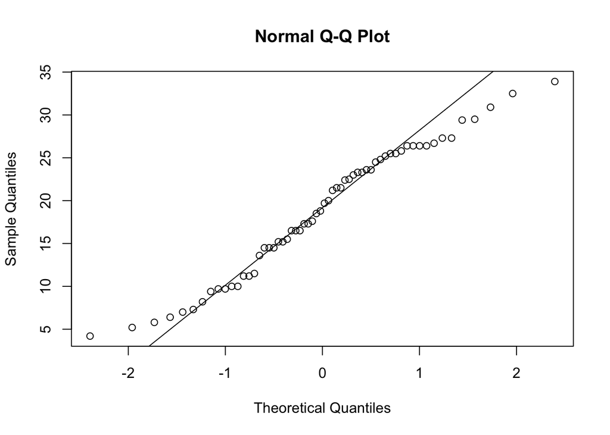

```r
qqnorm(ToothGrowth$len)
qqline(ToothGrowth$len)
```

**Conclusion:** The data are *not* normally distributed; the sample quantiles diverge from theoretical quantiles at the tails.

## 2B: Exploratory Linear Modeling

What the heck is going on? Load data from Frank, Vul, Saxe (2011, Infancy), a study in which we measured infants’ looking to hands in moving scenes. There were infants from 3 months all the way to about two years, and there were two movie conditions (`Faces_Medium`, in which kids played on a white background, and `Faces_Plus`, in which the backgrounds were more complex and the people in the videos were both kids and adults). Forgive our bad naming conventions.

Try to figure out what the most reasonable linear model of the data is.

```r
babies <- read.csv("../data/FVS2011-hands.csv")
baby.model <- lm(hand.look ~ condition, babies)
baby.model2 <- lm(hand.look ~ condition + age, babies)
baby.model3 <- lm(hand.look ~ condition * age, babies)
pander(AIC(baby.model, baby.model2, baby.model3))
```

|  | df | AIC |
| --- | --- | --- |
| **baby.model** | 3 | -647.9 |
| **baby.model2** | 4 | -681.4 |
| **baby.model3** | 5 | -685.2 |

```r
anova(baby.model, baby.model2, baby.model3)
```

```
## Analysis of Variance Table
##
## Model 1: hand.look ~ condition
## Model 2: hand.look ~ condition + age
## Model 3: hand.look ~ condition * age
##   Res.Df   RSS Df Sum of Sq     F  Pr(>F)
## 1    230 0.811
## 2    229 0.696  1     0.115 38.68 2.4e-09 ***
## 3    228 0.679  1     0.017  5.71   0.018 *
## ---
## Signif. codes:  0 '***' 0.001 '**' 0.01 '*' 0.05 '.' 0.1 ' ' 1
```

```r
summary(baby.model3)
```

```
##
## Call:
## lm(formula = hand.look ~ condition * age, data = babies)
##
## Residuals:
##      Min       1Q   Median       3Q      Max
## -0.19012 -0.03651 -0.00124  0.03209  0.23947
##
## Coefficients:
##                         Estimate Std. Error t value Pr(>|t|)
## (Intercept)              0.02239    0.01542    1.45   0.1477
## conditionFaces_Plus     -0.02844    0.02168   -1.31   0.1909
## age                      0.00314    0.00118    2.67   0.0081 **
## conditionFaces_Plus:age  0.00395    0.00165    2.39   0.0177 *
## ---
## Signif. codes:  0 '***' 0.001 '**' 0.01 '*' 0.05 '.' 0.1 ' ' 1
##
## Residual standard error: 0.0546 on 228 degrees of freedom
## Multiple R-squared:  0.187,  Adjusted R-squared:  0.176
## F-statistic: 17.5 on 3 and 228 DF,  p-value: 2.96e-10
```

**Conclusion:** Despite its complexity, the interactive model best captures the data.

Plot that model on the same plot as the data.

HINT: you can do this either using `predict` or (if you are feeling confident of your understanding of the models) using the built-in linear models in `ggplot`’s `geom_smooth`.

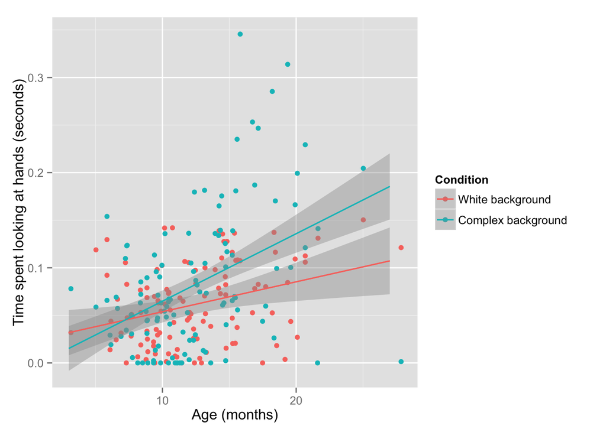

```r
# Create model estimates with SE
baby.line <- data.frame(age = rep(seq(3, 27, .25),2))
baby.line$condition <- rep(levels(babies$condition), each = nrow(baby.line)/2)
baby.predict <- predict(baby.model3, newdata = baby.line, se = T)
baby.line$hand.look <- baby.predict$fit
baby.line$se <- baby.predict$se.fit

# Plot predictions on data
ggplot(babies, aes(x = age, y = hand.look, colour = condition)) +
  geom_point() +
  geom_smooth(data = baby.line, aes(ymin = hand.look - 1.96*se, ymax = hand.look + 1.96*se),
              stat = "identity") +
  geom_line(data = baby.line, aes(se = se)) +
  xlab("Age (months)") +
  ylab("Time spent looking at hands (seconds)") +
  scale_colour_discrete(name = "Condition",
                        labels = c("White background", "Complex background"))
```

What do you conclude from this pattern of data?

**Conclusions:** There is a main effect of age on looking time: as children grow older, they attend more and more to hands ($\beta$ = 0.003, t = 2.67, p < 0.01). There is no effect of background type on infants’ attention to hands ($\beta$ = -0.03, t = -1.31, p = 0.19). There is, however, an interaction between condition and age: there is a more dramatic difference in looking time as a function of age in trials where hands were shown on a complex background, relative to trials where the hands were shown on a white background. These results suggest that infants’ attention sharpens with age: the oldest children in the study were able to override the distractors in the complex environment to attend to the hands. When hands were presented with hands on simple backgrounds, children again attended to the hands longer with age—these results suggest that older children are not just better able to ignore distractors, but also better able to attend to the hands.

# 3: Linear Mixed Effect Models

The goal here is to learn to use LMEMs using `lme4` and to compare them to standard by subject, by item LMs, as well as the standard (no repeated measures) fixed effects GLM.

The dataset here is from Stiller, Goodman, & Frank (2014), a paper on children’s pragmatic inferences. We saw the paradigm in the counterbalancing lecture: it’s three faces: a smiley, a smiley with glasses, and a smiley with a hat and glasses. When told “my friend has glasses” do kids pick the one with the glasses and no hat? `age.group` is the kids’ age group, `condition` is either “label,” described above, or “no label,” which was a control condition in which kids picked without hearing the term “glasses” at all.

```r
library(lme4)

d <- read.csv("../data/scales.csv")
d$age.group <- factor(d$age.group)
```

Always begin with a histogram!

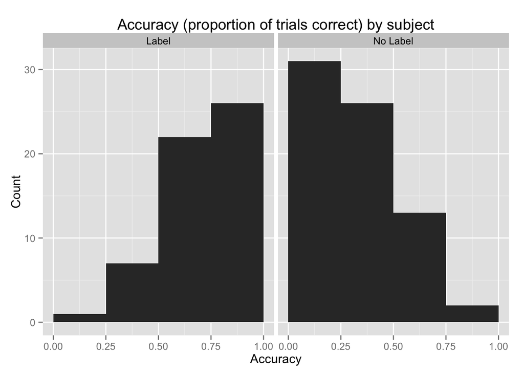

```r
# Summarise data to derive 'accuracy' measure from 'correct'
d.summ <- d %>%
  group_by(subid, condition) %>%
  summarise(age.group = unique(age.group),
            age = mean(age),
            accuracy = sum(correct)/length(correct))

# Plot histogram
ggplot(d.summ, aes(x = accuracy)) +
  geom_histogram(binwidth = 0.25) +
  xlim(0, 1) +
  facet_grid(~ condition) +
  ggtitle("Accuracy (proportion of trials correct) by subject") +
  xlab("Accuracy") +
  ylab("Count")
```

## Brief Confidence Interval Digression

Start out by setting up a function for a 95% CI using the normal approximation.

```r
sem <- function(x) {
  return(sd(x)/sqrt(length(x)))
}

ci95.norm <- function(x) {
  # Input: vector of measurements
  lim <- qnorm(0.975)*sem(x)
  return(c(mean(x)-lim, mean(x)+lim))
}
```

But the number of participants in a group is likely to be < 30, so let’s also compute this with a t distribution.

```r
ci95.t <- function(x) {
  lim <- qt(0.975, length(x)-1)*sem(x)
  return(c(mean(x)-lim, mean(x)+lim))
}
```

On the other hand, maybe we should use bootstrap CIs because these are actually proportions, and the normal/t approximations don’t know that they are 0/1 bounded.

```r
library(boot)
library(bootstrap)
```

Take a look at `?boot` and `?bootci`. Note that the syntax for the `boot` library is terrible, so we’re going to use it to check some code that I use:

```r
theta <- function(x,xdata,na.rm=T) {mean(xdata[x],na.rm=na.rm)}
ci.low <- function(x,na.rm=T) {
  mean(x,na.rm=na.rm) -
    quantile(bootstrap(1:length(x),
                       10000,theta,x,na.rm=na.rm)$thetastar,.025,na.rm=na.rm)}
ci.high <- function(x,na.rm=T) {
  quantile(bootstrap(1:length(x),
                     10000,theta,x,na.rm=na.rm)$thetastar,.975,na.rm=na.rm) -
    mean(x,na.rm=na.rm)}
```

Now make 95% confidence intervals across participants using all the methods above:

- Normal
- t
- Bootstrap percentile using `boot.ci`
- Bootstrap percentile using my code

```r
# Normal
ci95.norm(d.summ$accuracy)
```

```
## [1] 0.3935 0.5011
```

```r
# t-distribution
ci95.t(d.summ$accuracy)
```

```
## [1] 0.3931 0.5015
```

```r
# Bootstrap percentile (boot.ci)
mean.fun <- function(dat, idx) mean(dat[idx], na.rm = TRUE)
d.boot <- boot(d.summ$accuracy, mean.fun, R = 10000)
boot.ci(d.boot, type = "perc")
```

```
## BOOTSTRAP CONFIDENCE INTERVAL CALCULATIONS
## Based on 10000 bootstrap replicates
##
## CALL :
## boot.ci(boot.out = d.boot, type = "perc")
##
## Intervals :
## Level     Percentile
## 95%   ( 0.3929,  0.5000 )
## Calculations and Intervals on Original Scale
```

```r
# Bootstrap percentile (code provided)
c(ci.low(d.summ$accuracy), ci.high(d.summ$accuracy))
```

```
##    2.5%   97.5%
## 0.05442 0.05272
```

Now plot the data by age and condition using `dplyr` and `ggplot2`. Plot some CIs on here - extra credit if you plot all of them and compare visually (you’ll need `position = position_dodge()` or some other way to offset them).

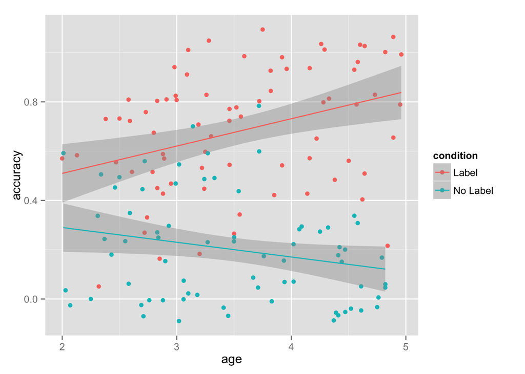

```r
ggplot(d.summ, aes(x = age, y = accuracy, colour = condition)) +
  geom_jitter() +
  geom_smooth(method = "lm")
```

What do you conclude about confidence interval computation?

## Back to LMEMs

```r
library(lme4)
```

OK, now do a basic GLM over the entire data frame, using `age.group`, `condition`, and their interaction to predict correctness. (If we were focusing on developmental issues, I would ask you to think about how to model age here, but let’s treat it as three discrete groups for now).

NOTE: this model is not appropriate, because it assumes that each subject’s observations are independent from one another. It’s still fine to do the analysis, though: it can tell you a lot about the data and is easy and fast to fit, as long as you know that you can’t trust the p-values!

```r
d.model <- glm(correct ~ age.group * condition, family = "binomial", d)
summary(d.model)
```

```
##
## Call:
## glm(formula = correct ~ age.group * condition, family = "binomial",
##     data = d)
##
## Deviance Residuals:
##    Min      1Q  Median      3Q     Max
## -1.717  -0.740  -0.517   0.825   2.039
##
## Coefficients:
##                              Estimate Std. Error z value Pr(>|z|)
## (Intercept)                     0.282      0.202    1.40  0.16290
## age.group3                      0.621      0.296    2.10  0.03593 *
## age.group4                      0.931      0.316    2.95  0.00320 **
## conditionNo Label              -1.437      0.313   -4.59  4.4e-06 ***
## age.group3:conditionNo Label   -0.621      0.449   -1.38  0.16705
## age.group4:conditionNo Label   -1.722      0.502   -3.43  0.00061 ***
## ---
## Signif. codes:  0 '***' 0.001 '**' 0.01 '*' 0.05 '.' 0.1 ' ' 1
##
## (Dispersion parameter for binomial family taken to be 1)
##
##     Null deviance: 808.59  on 587  degrees of freedom
## Residual deviance: 648.74  on 582  degrees of freedom
## AIC: 660.7
##
## Number of Fisher Scoring iterations: 4
```

Let’s now use `dplyr` to get data frames for by-items (`msi`) and by-subjects (`mss`) analyses. `msi` should contain the mean ratings for every item and `mss` should contain the mean ratings for every subject.

```r
msi <- d %>%
  group_by(trial, condition, age.group) %>%
  summarise(rating = mean(correct))

mss <- d%>%
  group_by(subid, condition, age.group) %>%
  summarise(rating = mean(correct))
```

Now do standard linear models on each of these.

NOTE: These are not strictly correct either because of the normal approximation on percent correct (model doesn’t know it’s 0 - 1 bounded and could give you standard error that goes above 1). Again, useful to do and see what happens.

```r
msi.model <- lm(rating ~ age.group * condition, msi)
summary(msi.model)
```

```
##
## Call:
## lm(formula = rating ~ age.group * condition, data = msi)
##
## Residuals:
##     Min      1Q  Median      3Q     Max
## -0.2115 -0.0772  0.0104  0.0733  0.2115
##
## Coefficients:
##                              Estimate Std. Error t value Pr(>|t|)
## (Intercept)                    0.5700     0.0548   10.39  4.9e-09 ***
## age.group3                     0.1415     0.0776    1.82  0.08469 .
## age.group4                     0.2008     0.0776    2.59  0.01852 *
## conditionNo Label             -0.3304     0.0776   -4.26  0.00047 ***
## age.group3:conditionNo Label  -0.1415     0.1097   -1.29  0.21329
## age.group4:conditionNo Label  -0.3154     0.1097   -2.88  0.01007 *
## ---
## Signif. codes:  0 '***' 0.001 '**' 0.01 '*' 0.05 '.' 0.1 ' ' 1
##
## Residual standard error: 0.11 on 18 degrees of freedom
## Multiple R-squared:  0.875,  Adjusted R-squared:  0.84
## F-statistic: 25.2 on 5 and 18 DF,  p-value: 1.52e-07
```

```r
mss.model <- lm(rating ~ age.group * condition, mss)
summary(mss.model)
```

```
##
## Call:
## lm(formula = rating ~ age.group * condition, data = mss)
##
## Residuals:
##     Min      1Q  Median      3Q     Max
## -0.5700 -0.2115  0.0104  0.1800  0.5104
##
## Coefficients:
##                              Estimate Std. Error t value Pr(>|t|)
## (Intercept)                    0.5700     0.0442   12.90  < 2e-16 ***
## age.group3                     0.1415     0.0619    2.29  0.02371 *
## age.group4                     0.2008     0.0632    3.18  0.00181 **
## conditionNo Label             -0.3304     0.0632   -5.23  5.9e-07 ***
## age.group3:conditionNo Label  -0.1415     0.0889   -1.59  0.11356
## age.group4:conditionNo Label  -0.3154     0.0898   -3.51  0.00059 ***
## ---
## Signif. codes:  0 '***' 0.001 '**' 0.01 '*' 0.05 '.' 0.1 ' ' 1
##
## Residual standard error: 0.221 on 141 degrees of freedom
## Multiple R-squared:  0.574,  Adjusted R-squared:  0.559
## F-statistic:   38 on 5 and 141 DF,  p-value: <2e-16
```

Do ANOVA on these. Note that ANOVA doesn’t let you figure out what is going on with individual levels of age.

```r
AIC(msi.model, mss.model)
```

```
##           df    AIC
## msi.model  7 -30.88
## mss.model  7 -18.79
```

**Conclusion:** I was not able to use ANOVA to compare the two models because the original dataset was compressed to a different number of groups. Instead, I used AIC to compare model fit. Based on this measure, it seems that item-wise performance is better predicted by condition and age group than subject-wise performance.

On to linear mixed effect models. Create the maximal random effects model a la Barr et al. (2013). Does it converge? If not, what will you do to make it converge? (The internet can be your friend here).

HINT: try simplifying your model to a “semi-maximal” model. Bonus: try using a different fitting procedure on the maximal model.

HINT: make sure that you consider which random effects are appropriate. Consider which observations are within/between subjects. E.g. having a random coefficient for age by subject doesn’t make sense, because each subject has only one age.

```r
full.model <- glmer(correct ~ condition * age.group + (1|subid) + (1|trial), family = "binomial", d)
summary(full.model)
```

```
## Generalized linear mixed model fit by maximum likelihood (Laplace
##   Approximation) [glmerMod]
##  Family: binomial  ( logit )
## Formula: correct ~ condition * age.group + (1 | subid) + (1 | trial)
##    Data: d
##
##      AIC      BIC   logLik deviance df.resid
##    661.2    696.2   -322.6    645.2      580
##
## Scaled residuals:
##    Min     1Q Median     3Q    Max
## -2.091 -0.605 -0.348  0.632  2.799
##
## Random effects:
##  Groups Name        Variance Std.Dev.
##  subid  (Intercept) 0.0539   0.232
##  trial  (Intercept) 0.0749   0.274
## Number of obs: 588, groups:  subid, 147; trial, 4
##
## Fixed effects:
##                              Estimate Std. Error z value Pr(>|z|)
## (Intercept)                     0.290      0.251    1.16  0.24770
## conditionNo Label              -1.479      0.330   -4.48  7.4e-06 ***
## age.group3                      0.639      0.309    2.07  0.03826 *
## age.group4                      0.957      0.329    2.91  0.00365 **
## conditionNo Label:age.group3   -0.640      0.465   -1.37  0.16944
## conditionNo Label:age.group4   -1.762      0.519   -3.39  0.00069 ***
## ---
## Signif. codes:  0 '***' 0.001 '**' 0.01 '*' 0.05 '.' 0.1 ' ' 1
##
## Correlation of Fixed Effects:
##             (Intr) cndtNL ag.gr3 ag.gr4 cNL:.3
## conditnNLbl -0.543
## age.group3  -0.566  0.417
## age.group4  -0.528  0.384  0.446
## cndtnNLb:.3  0.375 -0.671 -0.663 -0.296
## cndtnNLb:.4  0.333 -0.590 -0.287 -0.639  0.441
```

How do these coefficients compare with the independent coefficients linear model? What do you conclude?

**Conclusions:** Rather than treating ‘trial’ as a slope, I instead treated it as an intercept term. With this change, the model did converge Intuitively, a random intercept better captures any item-specific effects, as there is not a deep sequential relationship between trials that would be captured by a random slope term. Compared to the model with no mixed effects, the magnitude of the coefficients increased; this suggests that random item- and subject-specific variations in the data were muting differences between conditions and age groups.

Which random effects make the most difference? Find out using `ranef`. Plot the random effects for subject and item.

Make the minimal random effects model with just a subject intecept. How does this compare?

```r
subj.model <- glmer(correct ~ condition * age.group + (1|subid), family = "binomial", d)

anova(full.model, subj.model)
```

```
## Data: d
## Models:
## subj.model: correct ~ condition * age.group + (1 | subid)
## full.model: correct ~ condition * age.group + (1 | subid) + (1 | trial)
##            Df AIC BIC logLik deviance Chisq Chi Df Pr(>Chisq)
## subj.model  7 663 693   -324      649
## full.model  8 661 696   -323      645  3.48      1      0.062 .
## ---
## Signif. codes:  0 '***' 0.001 '**' 0.01 '*' 0.05 '.' 0.1 ' ' 1
```

**Conclusion:** The random effects model (AIC: 661.24) provides a marginally better fit of the data than the model without an intercept (AIC: 662.72; $\chi^2(1) = 3.48, p = 0.06$).

Get an estimate of the significance value for the coefficient on the `age*condition` interaction by using anova to compare between your semi-maximal model and the model without an intercept.

```r
anova(d.model, subj.model)
```

```
## Analysis of Deviance Table
##
## Model: binomial, link: logit
##
## Response: correct
##
## Terms added sequentially (first to last)
##
##
##                     Df Deviance Resid. Df Resid. Dev
## NULL                                  587        809
## age.group            2      2.4       585        806
## condition            1    145.1       584        661
## age.group:condition  2     12.4       582        649
```

```r
AIC(d.model, subj.model)
```

```
##            df   AIC
## d.model     6 660.7
## subj.model  7 662.7
```